# Machine Learning models with Credit Card defaults dataset

John Ray Martinez

### **Business Problem:**

Banks play a significant role in providing financial service to people. Due to competition, they must be careful when investing in clients to avoid financial loss and maintain the integrity. Hence, they must come to about the potential of customers before giving credit to borrowers.

For credit card domain, the credit scoring is used to measure the probability of clients’ default or failure to pay interest for principal on a loan or credit card payment. This credit scoring depends on some credit factors. Credit scoring models are usually constructed by logistic regression. For this assignment, I will determine and identify the credit factors using EDA (exploratory data analysis) and models Naive Bayes and Decision Tree. .

Overall, to reduce the risk of default and financial loss, the goal here is to find whether the clients are able to pay their next amount credit amount based on their demographics and payment history.

### **Date Source:**

The data is given in the CSV format, available at [Default of Credit Card Clients.](https://www.kaggle.com/uciml/default-of-credit-card-clients-dataset)

According to the site: *This dataset contains information on default payments, demographic factors, credit data, history of payment, and bill statements of credit card clients in Taiwan from April 2005 to September 2005.*

### **Data Preparation:**

| Default Payment | Freq |
| --- | --- |
| No | 23364 |
| Yes | 6636 |

| Default Payment | Percentage |
| --- | --- |
| No | 77.88 |
| Yes | 22.12 |

The internal structure of the dataset is shown below.

```
'data.frame':   30000 obs. of  25 variables:
 $ ID                        : int  1 2 3 4 5 6 7 8 9 10 ...
 $ LIMIT_BAL                 : num  20000 120000 90000 50000 50000 50000 500000 100000 140000 20000 ...
 $ SEX                       : int  2 2 2 2 1 1 1 2 2 1 ...
 $ EDUCATION                 : int  2 2 2 2 2 1 1 2 3 3 ...
 $ MARRIAGE                  : int  1 2 2 1 1 2 2 2 1 2 ...
 $ AGE                       : int  24 26 34 37 57 37 29 23 28 35 ...
 $ PAY_0                     : int  2 -1 0 0 -1 0 0 0 0 -2 ...
 $ PAY_2                     : int  2 2 0 0 0 0 0 -1 0 -2 ...
 $ PAY_3                     : int  -1 0 0 0 -1 0 0 -1 2 -2 ...
 $ PAY_4                     : int  -1 0 0 0 0 0 0 0 0 -2 ...
 $ PAY_5                     : int  -2 0 0 0 0 0 0 0 0 -1 ...
 $ PAY_6                     : int  -2 2 0 0 0 0 0 -1 0 -1 ...
 $ BILL_AMT1                 : num  3913 2682 29239 46990 8617 ...
 $ BILL_AMT2                 : num  3102 1725 14027 48233 5670 ...
 $ BILL_AMT3                 : num  689 2682 13559 49291 35835 ...
 $ BILL_AMT4                 : num  0 3272 14331 28314 20940 ...
 $ BILL_AMT5                 : num  0 3455 14948 28959 19146 ...
 $ BILL_AMT6                 : num  0 3261 15549 29547 19131 ...
 $ PAY_AMT1                  : num  0 0 1518 2000 2000 ...
 $ PAY_AMT2                  : num  689 1000 1500 2019 36681 ...
 $ PAY_AMT3                  : num  0 1000 1000 1200 10000 657 38000 0 432 0 ...
 $ PAY_AMT4                  : num  0 1000 1000 1100 9000 ...
 $ PAY_AMT5                  : num  0 0 1000 1069 689 ...
 $ PAY_AMT6                  : num  0 2000 5000 1000 679 ...
 $ default.payment.next.month: Factor w/ 2 levels "No","Yes": 2 2 1 1 1 1 1 1 1 1 ...
```

Here is the first 5 rows of the data.

```r
cc <- read.csv("C:/Users/john ray.000/Documents/INFO659/myrepo/UCI_Credit_Card.csv")
cc$default.payment.next.month <- factor(cc$default.payment.next.month,levels=c(0,1), labels=c("No","Yes"))
head(cc, 5)
```

|  | ID | LIMIT_BAL | SEX | EDUCATION | MARRIAGE | AGE | PAY_0 | PAY_2 | PAY_3 | PAY_4 | PAY_5 | PAY_6 | BILL_AMT1 | BILL_AMT2 | BILL_AMT3 | BILL_AMT4 | BILL_AMT5 | BILL_AMT6 | PAY_AMT1 | PAY_AMT2 | PAY_AMT3 | PAY_AMT4 | PAY_AMT5 | PAY_AMT6 | default.payment.next.month |
| --- | --- | --- | --- | --- | --- | --- | --- | --- | --- | --- | --- | --- | --- | --- | --- | --- | --- | --- | --- | --- | --- | --- | --- | --- | --- |
| 1 | 1 | 20000 | 2 | 2 | 1 | 24 | 2 | 2 | -1 | -1 | -2 | -2 | 3913 | 3102 | 689 | 0 | 0 | 0 | 0 | 689 | 0 | 0 | 0 | 0 | Yes |
| 2 | 2 | 120000 | 2 | 2 | 2 | 26 | -1 | 2 | 0 | 0 | 0 | 2 | 2682 | 1725 | 2682 | 3272 | 3455 | 3261 | 0 | 1000 | 1000 | 1000 | 0 | 2000 | Yes |
| 3 | 3 | 90000 | 2 | 2 | 2 | 34 | 0 | 0 | 0 | 0 | 0 | 0 | 29239 | 14027 | 13559 | 14331 | 14948 | 15549 | 1518 | 1500 | 1000 | 1000 | 1000 | 5000 | No |
| 4 | 4 | 50000 | 2 | 2 | 1 | 37 | 0 | 0 | 0 | 0 | 0 | 0 | 46990 | 48233 | 49291 | 28314 | 28959 | 29547 | 2000 | 2019 | 1200 | 1100 | 1069 | 1000 | No |
| 5 | 5 | 50000 | 1 | 2 | 1 | 57 | -1 | 0 | -1 | 0 | 0 | 0 | 8617 | 5670 | 35835 | 20940 | 19146 | 19131 | 2000 | 36681 | 10000 | 9000 | 689 | 679 | No |

### *Demographic Variables:*

I explored the two variables SEX and EDUCATION numerically and visually to see if there’s any correlation on payment default.

Those EDUCATION = 0, 5, 6 are unknown based in the data documentation. With that, I grouped them together and included in the value 4 (= others). Below is the distributions for EDUCATION and SEX variableS.

```r
cc$EDUCATION = ifelse(cc$EDUCATION == 0 |cc$EDUCATION == 5 | cc$EDUCATION == 6,
       4, cc$EDUCATION)
```

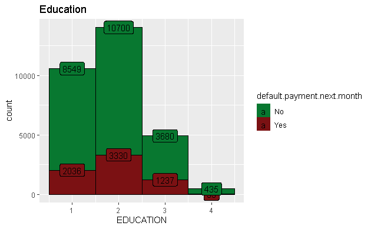

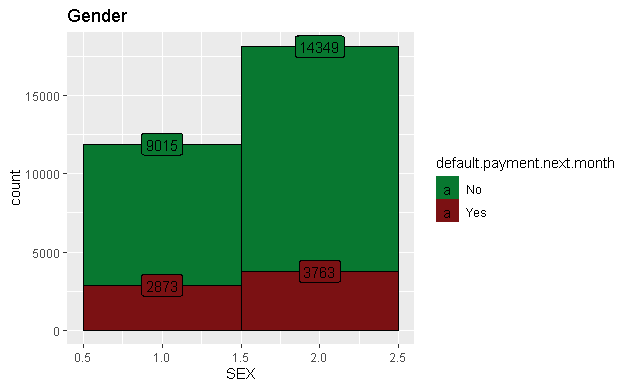

For EDUCATION, generally, there are lower chances to default if clients have better education. Those with High School levels have higher chances to default. The fraction of clients who have High School (EDUCATION = 3) degrees and are default clients is 25%. Similarly, around 24% of clients who have University (EDUCATION = 2) degrees are defaults. I also found out that 19% of clients who have graduate degrees or are in graduate schools are defaulters.

For SEX, generally, male persons have more chances to default. As shown on the plot, the male credit card clients have a higher percentage of defaults compared to female ones. Around 24% of MALE clients are defaulters while 21% of FEMALE clients are default.

### *Payment Status Variables:*

I randomly picked and explored the variables PAY_0, PAY_2, PAY_3 numerically and visually to see if there’s any correlation on payment default. According to data documentation, the possible values for these three variables are

*-1=pay duly, 1=payment delay for one month, 2=payment delay for two months, … 8=payment delay for eight months, 9=payment delay for nine months and above.*

- PAY_0 is the repayment status in September
- PAY_2 is the repayment status in August
- PAY_3 is the repayment status in July

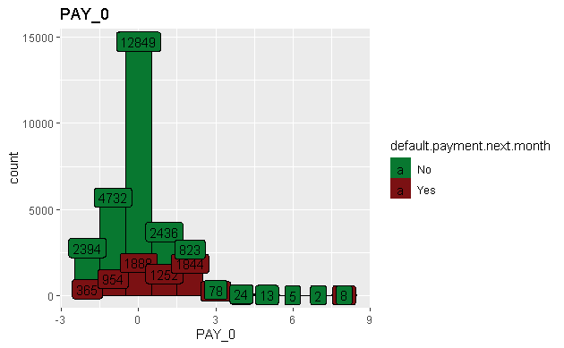

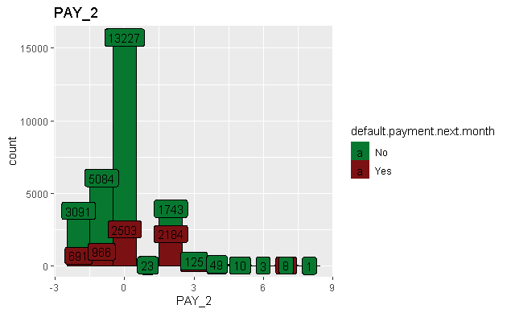

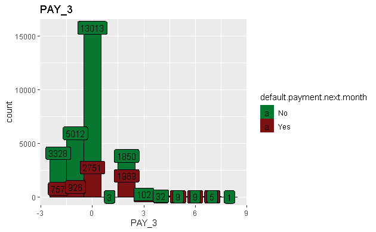

Notice, by inspecting the plots, that there are undocumented values such as -2 and 0 for repayment status variables.

I focused on looking at the values 2 (payment delay for two months) from these three predictors. The common trend for the three plots above is that the percentage of credit card defaults rose at this point where payment is delayed for two months. The chances of default goes higher when payment is delayed more than 2 months. For instance, for variable PAY_0, the percentage of defaulters are 33%, 69%, 75%, 68%, 50%, 55%, 78%, 58% for delay for 1…8 months respectively while those who pay on time has small chance of 17% to default. It is clear that credit card clients paying their bills with some delay have a higher percentage of defaults compared to clients paying on time.

I also confirmed the strong correlation of PAYMENT STATUS variables with DEFAULT variable through correlation plot below. The plot shows the positive correlation of PAY_0, PAY_1 - PAY_6 to DEFAULT variable.

*I converted column label default.payment.next.month to DEFAULT for plot aesthetic purposes.*

```r
colnames(cc)[colnames((cc)) == "default.payment.next.month"] = "DEFAULT"
```

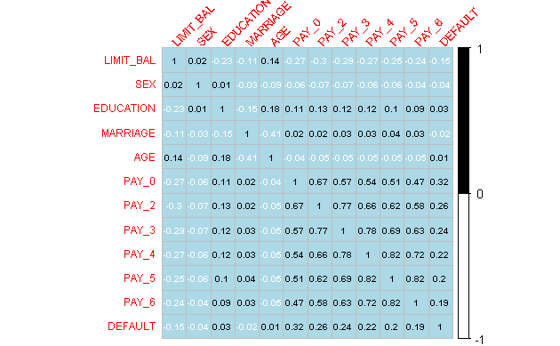

### *Transforming Nominal Variables:*

I decided to transform the 3 demographic variables (SEX, EDUCATION, MARRIAGE) into nominal values with labels according to data documentation.

```r
cc$SEX <- factor(cc$SEX,levels=c(1,2), labels=c("Male", "Female"))
```

|  | ID | LIMIT_BAL | SEX | EDUCATION | MARRIAGE | AGE | PAY_0 | PAY_2 | PAY_3 | PAY_4 | PAY_5 | PAY_6 | BILL_AMT1 | BILL_AMT2 | BILL_AMT3 | BILL_AMT4 | BILL_AMT5 | BILL_AMT6 | PAY_AMT1 | PAY_AMT2 | PAY_AMT3 | PAY_AMT4 | PAY_AMT5 | PAY_AMT6 | DEFAULT |
| --- | --- | --- | --- | --- | --- | --- | --- | --- | --- | --- | --- | --- | --- | --- | --- | --- | --- | --- | --- | --- | --- | --- | --- | --- | --- |
| 1 | 1 | 20000 | Female | 2 | 1 | 24 | 2 | 2 | -1 | -1 | -2 | -2 | 3913 | 3102 | 689 | 0 | 0 | 0 | 0 | 689 | 0 | 0 | 0 | 0 | Yes |
| 2 | 2 | 120000 | Female | 2 | 2 | 26 | -1 | 2 | 0 | 0 | 0 | 2 | 2682 | 1725 | 2682 | 3272 | 3455 | 3261 | 0 | 1000 | 1000 | 1000 | 0 | 2000 | Yes |
| 3 | 3 | 90000 | Female | 2 | 2 | 34 | 0 | 0 | 0 | 0 | 0 | 0 | 29239 | 14027 | 13559 | 14331 | 14948 | 15549 | 1518 | 1500 | 1000 | 1000 | 1000 | 5000 | No |
| 4 | 4 | 50000 | Female | 2 | 1 | 37 | 0 | 0 | 0 | 0 | 0 | 0 | 46990 | 48233 | 49291 | 28314 | 28959 | 29547 | 2000 | 2019 | 1200 | 1100 | 1069 | 1000 | No |
| 5 | 5 | 50000 | Male | 2 | 1 | 57 | -1 | 0 | -1 | 0 | 0 | 0 | 8617 | 5670 | 35835 | 20940 | 19146 | 19131 | 2000 | 36681 | 10000 | 9000 | 689 | 679 | No |

```r
cc$EDUCATION <- factor(cc$EDUCATION,levels=c(1,2,3,4), labels=c("graduate school", "university", "high school", "others"))
```

|  | ID | LIMIT_BAL | SEX | EDUCATION | MARRIAGE | AGE | PAY_0 | PAY_2 | PAY_3 | PAY_4 | PAY_5 | PAY_6 | BILL_AMT1 | BILL_AMT2 | BILL_AMT3 | BILL_AMT4 | BILL_AMT5 | BILL_AMT6 | PAY_AMT1 | PAY_AMT2 | PAY_AMT3 | PAY_AMT4 | PAY_AMT5 | PAY_AMT6 | DEFAULT |
| --- | --- | --- | --- | --- | --- | --- | --- | --- | --- | --- | --- | --- | --- | --- | --- | --- | --- | --- | --- | --- | --- | --- | --- | --- | --- |
| 1 | 1 | 20000 | Female | university | 1 | 24 | 2 | 2 | -1 | -1 | -2 | -2 | 3913 | 3102 | 689 | 0 | 0 | 0 | 0 | 689 | 0 | 0 | 0 | 0 | Yes |
| 2 | 2 | 120000 | Female | university | 2 | 26 | -1 | 2 | 0 | 0 | 0 | 2 | 2682 | 1725 | 2682 | 3272 | 3455 | 3261 | 0 | 1000 | 1000 | 1000 | 0 | 2000 | Yes |
| 3 | 3 | 90000 | Female | university | 2 | 34 | 0 | 0 | 0 | 0 | 0 | 0 | 29239 | 14027 | 13559 | 14331 | 14948 | 15549 | 1518 | 1500 | 1000 | 1000 | 1000 | 5000 | No |
| 4 | 4 | 50000 | Female | university | 1 | 37 | 0 | 0 | 0 | 0 | 0 | 0 | 46990 | 48233 | 49291 | 28314 | 28959 | 29547 | 2000 | 2019 | 1200 | 1100 | 1069 | 1000 | No |
| 5 | 5 | 50000 | Male | university | 1 | 57 | -1 | 0 | -1 | 0 | 0 | 0 | 8617 | 5670 | 35835 | 20940 | 19146 | 19131 | 2000 | 36681 | 10000 | 9000 | 689 | 679 | No |
| 6 | 6 | 50000 | Male | graduate school | 2 | 37 | 0 | 0 | 0 | 0 | 0 | 0 | 64400 | 57069 | 57608 | 19394 | 19619 | 20024 | 2500 | 1815 | 657 | 1000 | 1000 | 800 | No |
| 7 | 7 | 500000 | Male | graduate school | 2 | 29 | 0 | 0 | 0 | 0 | 0 | 0 | 367965 | 412023 | 445007 | 542653 | 483003 | 473944 | 55000 | 40000 | 38000 | 20239 | 13750 | 13770 | No |
| 8 | 8 | 100000 | Female | university | 2 | 23 | 0 | -1 | -1 | 0 | 0 | -1 | 11876 | 380 | 601 | 221 | -159 | 567 | 380 | 601 | 0 | 581 | 1687 | 1542 | No |
| 9 | 9 | 140000 | Female | high school | 1 | 28 | 0 | 0 | 2 | 0 | 0 | 0 | 11285 | 14096 | 12108 | 12211 | 11793 | 3719 | 3329 | 0 | 432 | 1000 | 1000 | 1000 | No |
| 10 | 10 | 20000 | Male | high school | 2 | 35 | -2 | -2 | -2 | -2 | -1 | -1 | 0 | 0 | 0 | 0 | 13007 | 13912 | 0 | 0 | 0 | 13007 | 1122 | 0 | No |

```r
unique(cc$MARRIAGE)
```

```
[1] 1 2 3 0
```

```r
cc$MARRIAGE = ifelse(cc$MARRIAGE == 3, 0, cc$MARRIAGE)
cc$MARRIAGE <- factor(cc$MARRIAGE,levels=c(1,2,3), labels=c("married","single","others"))
```

|  | ID | LIMIT_BAL | SEX | EDUCATION | MARRIAGE | AGE | PAY_0 | PAY_2 | PAY_3 | PAY_4 | PAY_5 | PAY_6 | BILL_AMT1 | BILL_AMT2 | BILL_AMT3 | BILL_AMT4 | BILL_AMT5 | BILL_AMT6 | PAY_AMT1 | PAY_AMT2 | PAY_AMT3 | PAY_AMT4 | PAY_AMT5 | PAY_AMT6 | DEFAULT |
| --- | --- | --- | --- | --- | --- | --- | --- | --- | --- | --- | --- | --- | --- | --- | --- | --- | --- | --- | --- | --- | --- | --- | --- | --- | --- |
| 1 | 1 | 20000 | Female | university | married | 24 | 2 | 2 | -1 | -1 | -2 | -2 | 3913 | 3102 | 689 | 0 | 0 | 0 | 0 | 689 | 0 | 0 | 0 | 0 | Yes |
| 2 | 2 | 120000 | Female | university | single | 26 | -1 | 2 | 0 | 0 | 0 | 2 | 2682 | 1725 | 2682 | 3272 | 3455 | 3261 | 0 | 1000 | 1000 | 1000 | 0 | 2000 | Yes |
| 3 | 3 | 90000 | Female | university | single | 34 | 0 | 0 | 0 | 0 | 0 | 0 | 29239 | 14027 | 13559 | 14331 | 14948 | 15549 | 1518 | 1500 | 1000 | 1000 | 1000 | 5000 | No |
| 4 | 4 | 50000 | Female | university | married | 37 | 0 | 0 | 0 | 0 | 0 | 0 | 46990 | 48233 | 49291 | 28314 | 28959 | 29547 | 2000 | 2019 | 1200 | 1100 | 1069 | 1000 | No |
| 5 | 5 | 50000 | Male | university | married | 57 | -1 | 0 | -1 | 0 | 0 | 0 | 8617 | 5670 | 35835 | 20940 | 19146 | 19131 | 2000 | 36681 | 10000 | 9000 | 689 | 679 | No |
| 6 | 6 | 50000 | Male | graduate school | single | 37 | 0 | 0 | 0 | 0 | 0 | 0 | 64400 | 57069 | 57608 | 19394 | 19619 | 20024 | 2500 | 1815 | 657 | 1000 | 1000 | 800 | No |
| 7 | 7 | 500000 | Male | graduate school | single | 29 | 0 | 0 | 0 | 0 | 0 | 0 | 367965 | 412023 | 445007 | 542653 | 483003 | 473944 | 55000 | 40000 | 38000 | 20239 | 13750 | 13770 | No |
| 8 | 8 | 100000 | Female | university | single | 23 | 0 | -1 | -1 | 0 | 0 | -1 | 11876 | 380 | 601 | 221 | -159 | 567 | 380 | 601 | 0 | 581 | 1687 | 1542 | No |
| 9 | 9 | 140000 | Female | high school | married | 28 | 0 | 0 | 2 | 0 | 0 | 0 | 11285 | 14096 | 12108 | 12211 | 11793 | 3719 | 3329 | 0 | 432 | 1000 | 1000 | 1000 | No |
| 10 | 10 | 20000 | Male | high school | single | 35 | -2 | -2 | -2 | -2 | -1 | -1 | 0 | 0 | 0 | 0 | 13007 | 13912 | 0 | 0 | 0 | 13007 | 1122 | 0 | No |

Furthermore, I transformed the PAYMENT STATUS variables (PAY_1, PAY_2 - PAY_6) into the nominal variables. I fixed what appears to be a typo in the column label from PAY_0 to PAY_1 to be consistent with BILL_AMT_1 and PAY_AMT1.

According to data documentation, the possible values for PAYMENT status are:

*(-1=pay duly, 1=payment delay for one month, 2=payment delay for two months, … 8=payment delay for eight months, 9=payment delay for nine months and above)*

However, upon inspection of the data, there exists -2 and 0. In addition, the range of values for these fields in the data is -2 to 8, hence there is no value 9. With that, I decided to transform these variables according to these mappings below,

```r
cc$PAY_1  <- factor(cc$PAY_1, levels=c(-2,-1,0,1,2,3,4,5,6,7,8), labels=c("No consumption of credit card", "Pay duly", "Pay minimum only", "Delay for 1 month", "Delay for 2 months", "Delay for 3 months", "Delay for 4 months",  "Delay for 5 months", "Delay for 6 months", "Delay for 7 months",  "Delay for 8 months"))
cc$PAY_2  <- factor(cc$PAY_2, levels=c(-2,-1,0,1,2,3,4,5,6,7,8), labels=c("No consumption of credit card", "Pay duly", "Pay minimum only", "Delay for 1 month", "Delay for 2 months", "Delay for 3 months", "Delay for 4 months",  "Delay for 5 months", "Delay for 6 months", "Delay for 7 months",  "Delay for 8 months"))
cc$PAY_3  <- factor(cc$PAY_3, levels=c(-2,-1,0,1,2,3,4,5,6,7,8), labels=c("No consumption of credit card", "Pay duly", "Pay minimum only", "Delay for 1 month", "Delay for 2 months", "Delay for 3 months", "Delay for 4 months",  "Delay for 5 months", "Delay for 6 months", "Delay for 7 months",  "Delay for 8 months"))
cc$PAY_4  <- factor(cc$PAY_4, levels=c(-2,-1,0,1,2,3,4,5,6,7,8), labels=c("No consumption of credit card", "Pay duly", "Pay minimum only", "Delay for 1 month", "Delay for 2 months", "Delay for 3 months", "Delay for 4 months",  "Delay for 5 months", "Delay for 6 months", "Delay for 7 months",  "Delay for 8 months"))
cc$PAY_5  <- factor(cc$PAY_5, levels=c(-2,-1,0,1,2,3,4,5,6,7,8), labels=c("No consumption of credit card", "Pay duly", "Pay minimum only", "Delay for 1 month", "Delay for 2 months", "Delay for 3 months", "Delay for 4 months",  "Delay for 5 months", "Delay for 6 months", "Delay for 7 months",  "Delay for 8 months"))
cc$PAY_6  <- factor(cc$PAY_6, levels=c(-2,-1,0,1,2,3,4,5,6,7,8), labels=c("No consumption of credit card", "Pay duly", "Pay minimum only", "Delay for 1 month", "Delay for 2 months", "Delay for 3 months", "Delay for 4 months",  "Delay for 5 months", "Delay for 6 months", "Delay for 7 months",  "Delay for 8 months"))
```

|  | ID | LIMIT_BAL | SEX | EDUCATION | MARRIAGE | AGE | PAY_1 | PAY_2 | PAY_3 | PAY_4 | PAY_5 | PAY_6 | BILL_AMT1 | BILL_AMT2 | BILL_AMT3 | BILL_AMT4 | BILL_AMT5 | BILL_AMT6 | PAY_AMT1 | PAY_AMT2 | PAY_AMT3 | PAY_AMT4 | PAY_AMT5 | PAY_AMT6 | DEFAULT |
| --- | --- | --- | --- | --- | --- | --- | --- | --- | --- | --- | --- | --- | --- | --- | --- | --- | --- | --- | --- | --- | --- | --- | --- | --- | --- |
| 1 | 1 | 20000 | Female | university | married | 24 | Delay for 2 months | Delay for 2 months | Pay duly | Pay duly | No consumption of credit card | No consumption of credit card | 3913 | 3102 | 689 | 0 | 0 | 0 | 0 | 689 | 0 | 0 | 0 | 0 | Yes |
| 2 | 2 | 120000 | Female | university | single | 26 | Pay duly | Delay for 2 months | Pay minimum only | Pay minimum only | Pay minimum only | Delay for 2 months | 2682 | 1725 | 2682 | 3272 | 3455 | 3261 | 0 | 1000 | 1000 | 1000 | 0 | 2000 | Yes |
| 3 | 3 | 90000 | Female | university | single | 34 | Pay minimum only | Pay minimum only | Pay minimum only | Pay minimum only | Pay minimum only | Pay minimum only | 29239 | 14027 | 13559 | 14331 | 14948 | 15549 | 1518 | 1500 | 1000 | 1000 | 1000 | 5000 | No |
| 4 | 4 | 50000 | Female | university | married | 37 | Pay minimum only | Pay minimum only | Pay minimum only | Pay minimum only | Pay minimum only | Pay minimum only | 46990 | 48233 | 49291 | 28314 | 28959 | 29547 | 2000 | 2019 | 1200 | 1100 | 1069 | 1000 | No |
| 5 | 5 | 50000 | Male | university | married | 57 | Pay duly | Pay minimum only | Pay duly | Pay minimum only | Pay minimum only | Pay minimum only | 8617 | 5670 | 35835 | 20940 | 19146 | 19131 | 2000 | 36681 | 10000 | 9000 | 689 | 679 | No |
| 6 | 6 | 50000 | Male | graduate school | single | 37 | Pay minimum only | Pay minimum only | Pay minimum only | Pay minimum only | Pay minimum only | Pay minimum only | 64400 | 57069 | 57608 | 19394 | 19619 | 20024 | 2500 | 1815 | 657 | 1000 | 1000 | 800 | No |
| 7 | 7 | 500000 | Male | graduate school | single | 29 | Pay minimum only | Pay minimum only | Pay minimum only | Pay minimum only | Pay minimum only | Pay minimum only | 367965 | 412023 | 445007 | 542653 | 483003 | 473944 | 55000 | 40000 | 38000 | 20239 | 13750 | 13770 | No |
| 8 | 8 | 100000 | Female | university | single | 23 | Pay minimum only | Pay duly | Pay duly | Pay minimum only | Pay minimum only | Pay duly | 11876 | 380 | 601 | 221 | -159 | 567 | 380 | 601 | 0 | 581 | 1687 | 1542 | No |
| 9 | 9 | 140000 | Female | high school | married | 28 | Pay minimum only | Pay minimum only | Delay for 2 months | Pay minimum only | Pay minimum only | Pay minimum only | 11285 | 14096 | 12108 | 12211 | 11793 | 3719 | 3329 | 0 | 432 | 1000 | 1000 | 1000 | No |
| 10 | 10 | 20000 | Male | high school | single | 35 | No consumption of credit card | No consumption of credit card | No consumption of credit card | No consumption of credit card | Pay duly | Pay duly | 0 | 0 | 0 | 0 | 13007 | 13912 | 0 | 0 | 0 | 13007 | 1122 | 0 | No |

### *Selection of Training Data:*

Naive Bayes computes the conditional probabilites of categorical class variable (DEFAULT) given ‘independent’ predictor variables (SEX, EDUCATION, MARRIAGE).

```r
unique(cc$DEFAULT)
```

```
[1] Yes No
Levels: No Yes
```

I need to drop ID column since it’s unnecessary for the modeling.

```r
cc <- cc[ -c(1) ]
head(cc, 5)
```

|  | LIMIT_BAL | SEX | EDUCATION | MARRIAGE | AGE | PAY_1 | PAY_2 | PAY_3 | PAY_4 | PAY_5 | PAY_6 | BILL_AMT1 | BILL_AMT2 | BILL_AMT3 | BILL_AMT4 | BILL_AMT5 | BILL_AMT6 | PAY_AMT1 | PAY_AMT2 | PAY_AMT3 | PAY_AMT4 | PAY_AMT5 | PAY_AMT6 | DEFAULT |
| --- | --- | --- | --- | --- | --- | --- | --- | --- | --- | --- | --- | --- | --- | --- | --- | --- | --- | --- | --- | --- | --- | --- | --- | --- |
| 1 | 20000 | Female | university | married | 24 | Delay for 2 months | Delay for 2 months | Pay duly | Pay duly | No consumption of credit card | No consumption of credit card | 3913 | 3102 | 689 | 0 | 0 | 0 | 0 | 689 | 0 | 0 | 0 | 0 | Yes |
| 2 | 120000 | Female | university | single | 26 | Pay duly | Delay for 2 months | Pay minimum only | Pay minimum only | Pay minimum only | Delay for 2 months | 2682 | 1725 | 2682 | 3272 | 3455 | 3261 | 0 | 1000 | 1000 | 1000 | 0 | 2000 | Yes |
| 3 | 90000 | Female | university | single | 34 | Pay minimum only | Pay minimum only | Pay minimum only | Pay minimum only | Pay minimum only | Pay minimum only | 29239 | 14027 | 13559 | 14331 | 14948 | 15549 | 1518 | 1500 | 1000 | 1000 | 1000 | 5000 | No |
| 4 | 50000 | Female | university | married | 37 | Pay minimum only | Pay minimum only | Pay minimum only | Pay minimum only | Pay minimum only | Pay minimum only | 46990 | 48233 | 49291 | 28314 | 28959 | 29547 | 2000 | 2019 | 1200 | 1100 | 1069 | 1000 | No |
| 5 | 50000 | Male | university | married | 57 | Pay duly | Pay minimum only | Pay duly | Pay minimum only | Pay minimum only | Pay minimum only | 8617 | 5670 | 35835 | 20940 | 19146 | 19131 | 2000 | 36681 | 10000 | 9000 | 689 | 679 | No |

I selected 5000 random rows as training data.

```r
nrow(train)
```

```
[1] 5000
```

|  | LIMIT_BAL | SEX | EDUCATION | MARRIAGE | AGE | PAY_1 | PAY_2 | PAY_3 | PAY_4 | PAY_5 | PAY_6 | BILL_AMT1 | BILL_AMT2 | BILL_AMT3 | BILL_AMT4 | BILL_AMT5 | BILL_AMT6 | PAY_AMT1 | PAY_AMT2 | PAY_AMT3 | PAY_AMT4 | PAY_AMT5 | PAY_AMT6 | DEFAULT |
| --- | --- | --- | --- | --- | --- | --- | --- | --- | --- | --- | --- | --- | --- | --- | --- | --- | --- | --- | --- | --- | --- | --- | --- | --- |
| 4162 | 200000 | Female | university | married | 44 | Delay for 1 month | Delay for 2 months | Delay for 2 months | Delay for 2 months | Pay minimum only | Pay minimum only | 2667 | 2478 | 6406 | 6216 | 5258 | 7002 | 0 | 4000 | 14 | 2000 | 2000 | 2000 | Yes |
| 7220 | 160000 | Female | university | married | 26 | Pay duly | Pay duly | Pay duly | Pay duly | Pay duly | Pay duly | 1319 | 3934 | 399 | 690 | 590 | 0 | 3941 | 399 | 690 | 590 | 0 | 1926 | Yes |
| 19697 | 470000 | Female | graduate school | married | 37 | Pay minimum only | Pay minimum only | Pay minimum only | Pay minimum only | Pay minimum only | Pay minimum only | 163000 | 160298 | 135683 | 128719 | 116173 | 104283 | 10047 | 5001 | 6010 | 4512 | 4012 | 3522 | No |
| 10903 | 30000 | Female | university | single | 31 | Pay minimum only | Pay minimum only | Pay minimum only | Pay minimum only | Pay minimum only | Pay minimum only | 28716 | 26570 | 26829 | 26839 | 27449 | 25125 | 2000 | 1600 | 1000 | 1000 | 1000 | 0 | No |
| 9444 | 150000 | Male | graduate school | single | 31 | Pay duly | Pay duly | Pay duly | Pay duly | Pay minimum only | Pay minimum only | 3084 | -1 | 600 | 4102 | 4102 | 6121 | 0 | 601 | 4102 | 0 | 2019 | 5515 | No |

### *Selection of Testing Data:*

I randomnly picked these two rows below as test data.

|  | LIMIT_BAL | SEX | EDUCATION | MARRIAGE | AGE | PAY_1 | PAY_2 | PAY_3 | PAY_4 | PAY_5 | PAY_6 | BILL_AMT1 | BILL_AMT2 | BILL_AMT3 | BILL_AMT4 | BILL_AMT5 | BILL_AMT6 | PAY_AMT1 | PAY_AMT2 | PAY_AMT3 | PAY_AMT4 | PAY_AMT5 | PAY_AMT6 | DEFAULT |
| --- | --- | --- | --- | --- | --- | --- | --- | --- | --- | --- | --- | --- | --- | --- | --- | --- | --- | --- | --- | --- | --- | --- | --- | --- |
| 6955 | 3e+05 | Female | graduate school | single | 33 | No consumption of credit card | No consumption of credit card | No consumption of credit card | No consumption of credit card | No consumption of credit card | No consumption of credit card | 0 | 0 | 0 | 0 | 0 | 0 | 0 | 0 | 0 | 0 | 0 | 0 | Yes |
| 29095 | 8e+04 | Female | high school | married | 56 | Pay duly | Pay minimum only | Pay minimum only | Pay minimum only | No consumption of credit card | No consumption of credit card | 1407 | 2445 | 3377 | -6 | 2188 | 5808 | 1068 | 1000 | 6 | 2194 | 5825 | 0 | No |

### **Data Classification:**

### *Naive Bayes using Demographic Variables:*

```r
nbDem <- naiveBayes(DEFAULT ~ SEX + EDUCATION + MARRIAGE, train)
```

```r
nbDem
```

```
Naive Bayes Classifier for Discrete Predictors

Call:
naiveBayes.default(x = X, y = Y, laplace = laplace)

A-priori probabilities:
Y
    No    Yes
0.7744 0.2256

Conditional probabilities:
     SEX
Y          Male    Female
  No  0.3850723 0.6149277
  Yes 0.4450355 0.5549645

     EDUCATION
Y     graduate school  university high school      others
  No      0.351720515 0.475702653 0.166535330 0.006041502
  Yes     0.325912734 0.489759573 0.184327694 0.000000000

     MARRIAGE
Y       married    single    others
  No  0.4501961 0.5498039 0.0000000
  Yes 0.4739209 0.5260791 0.0000000
```

Looking at the generated probabilites of the model, it is clear that the sum of the probabilities horizontally will give 1 as expected since the total of all probabilities should be 1. For instance, the sum of probabilities of male (0.45) and female (0.55) to be defaulters is 1. Similarly, the the sum of probabilities of married (0.47) and single (0.53) to be defaulters is 1.

```r
predict(nbDem, test[1,])
```

```
[1] No
Levels: No Yes
```

```r
predict(nbDem, test[2,])
```

```
[1] No
Levels: No Yes
```

Naive Bayes assumes predictors are conditionally independent, that is SEX, EDUCATION, and MARRIAGE are independent of one another which does not hold true in the real world. Remember, I trained the Naive Bayes using real world dataset. That assumption would be the disadvantage of Naive bayes which could be potential cause of errors in prediction.

### *Naive Bayes using Payment Status:*

```r
nbPay <- naiveBayes(DEFAULT ~ PAY_1 + PAY_2 + PAY_3, train)
```

```r
nbPay
```

```
Naive Bayes Classifier for Discrete Predictors

Call:
naiveBayes.default(x = X, y = Y, laplace = laplace)

A-priori probabilities:
Y
    No    Yes
0.7744 0.2256

Conditional probabilities:
     PAY_1
Y     No consumption of credit card     Pay duly Pay minimum only
  No                   0.1058884298 0.1942148760     0.5493285124
  Yes                  0.0514184397 0.1445035461     0.2739361702
     PAY_1
Y     Delay for 1 month Delay for 2 months Delay for 3 months
  No       0.1120867769       0.0317665289       0.0046487603
  Yes      0.1773049645       0.2952127660       0.0381205674
     PAY_1
Y     Delay for 4 months Delay for 5 months Delay for 6 months
  No        0.0012913223       0.0005165289       0.0002582645
  Yes       0.0106382979       0.0008865248       0.0026595745
     PAY_1
Y     Delay for 7 months Delay for 8 months
  No        0.0000000000       0.0000000000
  Yes       0.0026595745       0.0026595745

     PAY_2
Y     No consumption of credit card     Pay duly Pay minimum only
  No                   0.1371384298 0.2156508264     0.5596590909
  Yes                  0.0895390071 0.1498226950     0.3758865248
     PAY_2
Y     Delay for 1 month Delay for 2 months Delay for 3 months
  No       0.0007747934       0.0785123967       0.0049070248
  Yes      0.0000000000       0.3324468085       0.0363475177
     PAY_2
Y     Delay for 4 months Delay for 5 months Delay for 6 months
  No        0.0028409091       0.0002582645       0.0000000000
  Yes       0.0062056738       0.0035460993       0.0035460993
     PAY_2
Y     Delay for 7 months Delay for 8 months
  No        0.0000000000       0.0002582645
  Yes       0.0026595745       0.0000000000

     PAY_3
Y     No consumption of credit card     Pay duly Pay minimum only
  No                   0.1528925620 0.2097107438     0.5490702479
  Yes                  0.0975177305 0.1471631206     0.4086879433
     PAY_3
Y     Delay for 1 month Delay for 2 months Delay for 3 months
  No       0.0000000000       0.0803202479       0.0059400826
  Yes      0.0000000000       0.3014184397       0.0248226950
     PAY_3
Y     Delay for 4 months Delay for 5 months Delay for 6 months
  No        0.0012913223       0.0002582645       0.0000000000
  Yes       0.0053191489       0.0044326241       0.0035460993
     PAY_3
Y     Delay for 7 months Delay for 8 months
  No        0.0005165289       0.0000000000
  Yes       0.0070921986       0.0000000000
```

For Payment Status predictors, the sum of the generated conditional probabilites of the model is 1 expectedly since the total of all probabilities should be 1. For PAY_1 or the repayment status in September (2005), for instance, the sum of the conditional probabilities of the following status to be defaulters is 1.

0.0514184397 (No consumption of credit card) 0.1445035461 (Pay duly)  
0.2739361702 (Pay minimum only) 0.1773049645 (Delay for 1 month)  
0.2952127660 (Delay for 2 month)  
0.0381205674 (Delay for 3 month) 0.0106382979 (Delay for 4 month)  
0.0008865248 (Delay for 5 month)  
0.0026595745 (Delay for 6 month) 0.0026595745 (Delay for 7 month) 0.0026595745 (Delay for 8 month)

1.0000000000

```r
predict(nbPay, test[1,])
```

```
[1] No
Levels: No Yes
```

```r
predict(nbPay, test[2,])
```

```
[1] No
Levels: No Yes
```

DEFAULT=NO  
PAY_1: 0.1058884298 PAY_2: 0.1371384298 PAY_3: 0.1528925620

DEFAULT=Yes  
PAY_1: 0.0514184397 PAY_2: 0.0895390071 PAY_3: 0.0975177305

In the case of test record 2, the value for PAY_1 is ‘Pay duly’ while for PAY_2 and PAY_3 it is ‘Pay minimum only’. In conditional probability table below for test record 2, I can confirm that the prediction of the model that the particular client to be non-defaulter for test record 2 is correct numerically.

DEFAULT=NO  
PAY_1: 0.1942148760 PAY_2: 0.5596590909 PAY_3: 0.5490702479

DEFAULT=Yes  
PAY_1: 0.1445035461 PAY_2: 0.3758865248 PAY_3: 0.4086879433

### *Smoothed Naive Bayes using Payment Status*

```r
nbPay <- naiveBayes(DEFAULT ~ PAY_1 + PAY_2 + PAY_3, train, laplace=1)
```

```r
nbPay
```

```
Naive Bayes Classifier for Discrete Predictors

Call:
naiveBayes.default(x = X, y = Y, laplace = laplace)

A-priori probabilities:
Y
    No    Yes
0.7744 0.2256

Conditional probabilities:
     PAY_1
Y     No consumption of credit card     Pay duly Pay minimum only
  No                   0.1058459954 0.1939222251     0.5480298738
  Yes                  0.0517998244 0.1439859526     0.2721685689
     PAY_1
Y     Delay for 1 month Delay for 2 months Delay for 3 months
  No       0.1120267834       0.0319340716       0.0048931239
  Yes      0.1764705882       0.2932396839       0.0386303775
     PAY_1
Y     Delay for 4 months Delay for 5 months Delay for 6 months
  No        0.0015451970       0.0007725985       0.0005150657
  Yes       0.0114135206       0.0017559263       0.0035118525
     PAY_1
Y     Delay for 7 months Delay for 8 months
  No        0.0002575328       0.0002575328
  Yes       0.0035118525       0.0035118525

     PAY_2
Y     No consumption of credit card     Pay duly Pay minimum only
  No                   0.1370074685 0.2152974504     0.5583311872
  Yes                  0.0895522388 0.1492537313     0.3731343284
     PAY_2
Y     Delay for 1 month Delay for 2 months Delay for 3 months
  No       0.0010301313       0.0785475148       0.0051506567
  Yes      0.0008779631       0.3301141352       0.0368744513
     PAY_2
Y     Delay for 4 months Delay for 5 months Delay for 6 months
  No        0.0030903940       0.0005150657       0.0002575328
  Yes       0.0070237050       0.0043898156       0.0043898156
     PAY_2
Y     Delay for 7 months Delay for 8 months
  No        0.0002575328       0.0005150657
  Yes       0.0035118525       0.0008779631

     PAY_3
Y     No consumption of credit card     Pay duly Pay minimum only
  No                   0.1527169714 0.2093741952     0.5477723410
  Yes                  0.0974539069 0.1466198420     0.4056189640
     PAY_3
Y     Delay for 1 month Delay for 2 months Delay for 3 months
  No       0.0002575328       0.0803502447       0.0061807881
  Yes      0.0008779631       0.2993854258       0.0254609306
     PAY_3
Y     Delay for 4 months Delay for 5 months Delay for 6 months
  No        0.0015451970       0.0005150657       0.0002575328
  Yes       0.0061457419       0.0052677788       0.0043898156
     PAY_3
Y     Delay for 7 months Delay for 8 months
  No        0.0007725985       0.0002575328
  Yes       0.0079016681       0.0008779631
```

Notice that from (non-laplace) Naive Bayes model from previous section, there are generated zero probabilities. Those categories (PAY_3/Delay for 1 month, PAY_3/Delay for 8 months, etc) are not observed in training dateset. Hence the model assigned ‘zero’ probabilities. However, ‘zero’ probabilities do not make sense especially if the model is operating on unseen data.

To avoid zero probabilities for those unobserved data, smoothing techniques are used. One of the techniques is called Laplace. The generated conditional probabilities for smoothed Naive Bayes model with laplace = 1 are shown above. It is clear that the laplace smoothing has effect on ‘zero’ probabilities as all the conditional probabilities are now non-zero.

Similarly, the sum of the generated conditional probabilites of the laplace model is 1 expectedly since the total of all probabilities should be 1. For PAY_1 or the repayment status in September (2005), for instance, the sum of the new conditional probabilities of the following status to be defaulters is still 1.

0.0517998244 (No consumption of credit card) 0.1439859526 (Pay duly)  
0.2721685689 (Pay minimum only) 0.1764705882 (Delay for 1 month)  
0.2932396839 (Delay for 2 month) 0.0386303775 (Delay for 3 month) 0.0114135206 (Delay for 4 month)  
0.0017559263 (Delay for 5 month)  
0.0035118525 (Delay for 6 month) 0.0035118525 (Delay for 7 month)  
0.0035118525 (Delay for 8 month)

1.0000000000

```r
predict(nbPay, test[1,])
```

```
[1] No
Levels: No Yes
```

```r
predict(nbPay, test[2,])
```

```
[1] No
Levels: No Yes
```

### **Data Classification:**

### *Basic Decision Tree:*

```r
dtPay <- rpart(DEFAULT ~ PAY_1 + PAY_2 + PAY_3,
            method="class",
            data=train, parms=list(split='information'),
            minsplit=20, cp=0.02)
```

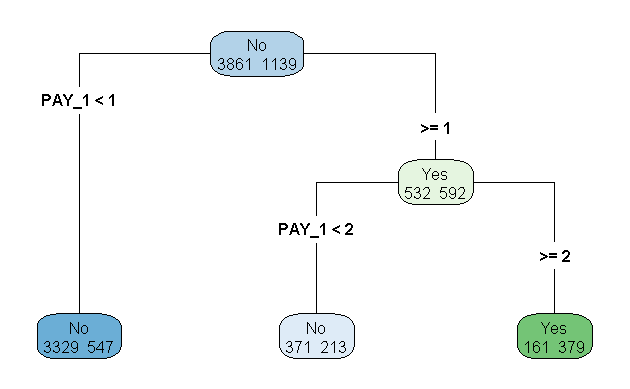

```r
rpart.plot(dtPay, type=4, extra=1)
```

As you can see in the plot above, the data is split into 5 nodes and 3 terminal nodes. Notice also that it performs feature selection as it only put the predictor PAY_1 on its tree and neglect the last 2 variables. In addition, it confirmed our analysis during EDA part earlier that when payment is delayed for more than 1 month, the chance of default goes higher than 50%, as shown in the ‘yes’ (green node) path from the plot.

```r
predict(dtPay, test[1,])
```

```
            No       Yes
6955 0.8588751 0.1411249
```

```r
predict(dtPay, test[2,])
```

```
             No       Yes
29095 0.8588751 0.1411249
```

For the test records ‘6955’ and ‘29095’, the PAY_1 variable has values -2 and -1 respectively. From the decision tree above, it has a chance of 14% (1 - 3329/3861) to be classified as defaulter. Similarly, since test record no 2 has PAY_1 of -1 which is still < 1, it has 14% to be defaulter.

### *Decision Tree with a Different Complexity Parameter:*

```r
dtPay <- rpart(DEFAULT ~ PAY_1 + PAY_2 + PAY_3,
            method="class",
            data=train, parms=list(split='information'),
            minsplit=20, cp=0.001)
```

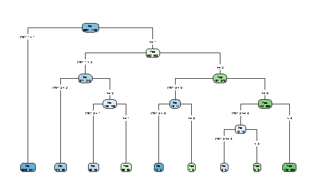

The complexity parameter is used to control the size of the decision tree and to select the optimal tree size. So changing the complexity parameter of the decision tree from 0.02 to 0.001 is a nice step to use the optimal tree size. Notice that it includes now the predictors PAY_2 and PAY_3 to the tree. From 5 nodes with 3 terminal nodes, the decision trees grow into 17 nodes with 9 terminal nodes.

```r
predict(dtPay, test[1,])
```

```
            No       Yes
6955 0.8588751 0.1411249
```

```r
predict(dtPay, test[2,])
```

```
             No       Yes
29095 0.8588751 0.1411249
```

```r
printcp(dtPay)
```

```
Classification tree:
rpart(formula = DEFAULT ~ PAY_1 + PAY_2 + PAY_3, data = train,
    method = "class", parms = list(split = "information"), minsplit = 20,
    cp = 0.001)

Variables actually used in tree construction:
[1] PAY_1 PAY_2 PAY_3

Root node error: 1139/5000 = 0.2278

n= 5000

         CP nsplit rel error  xerror     xstd
1 0.0956980      0   1.00000 1.00000 0.026038
2 0.0070237      2   0.80860 0.80860 0.024066
3 0.0061457      3   0.80158 0.81475 0.024136
4 0.0017559      5   0.78929 0.79104 0.023861
5 0.0013169      6   0.78753 0.79807 0.023944
6 0.0010000      8   0.78490 0.79807 0.023944
```

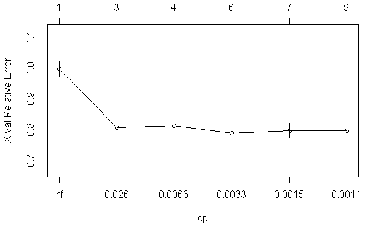

### **Conclusion:**

Based on the correlation plot that I created in EDA phase, the predictor LIMIT_BAL (Amount of given credit in NT dollars) has negative correlation of 0.15 to DEFAULT variable. This predictor can be considered for future research to see whether there is indeed a relationship of having a small LIMIT_BAL will lead to default accounts.

From the insight I gain from EDA and classification using Naive Bayes and Decision Tree models, I may propose to the risk management department the following to reduce the risk of default.

- More cautious on payment behavoiur of the clients
- More cautious on high school level clients
- More cautious on Male over Female

### **References:**

[1] UCI Machine Learning, Default of Credit Card Clients Dataset (2005), Kaggle